# Feature Engineering and Principal Components Analysis in R

**May 2018**

### **Author:** Lauren Washington

**Bio:** Lauren Washington is currently the Lead Data Scientist and Machine Learning Developer for smartQED (https://www.smartqed.com), an AI driven start-up. Lauren worked as a Data Scientist for Topix, Payments Risk Strategist for Google (Google Wallet/Android Pay), Statistical Analyst for Nielsen, and Big Data Intern for the National Opinion Research Center through the University of Chicago.

Lauren is also passionate about teaching Machine Learning. She’s currently giving back to the Data Science community as a Thinkful Data Science Bootcamp Mentor (https://www.thinkful.com) and a Packt Publishing technical video reviewer.

She also earned a Data Science certificate from General Assembly San Francisco (2016), a MA in the Quantitative Methods in the Social Sciences (Applied Statistical Methods) from Columbia University (2012), and a BA in Economics from Spelman College (2010).

**Follow her on Instagram:** @the_data_science_gal  
Check out her **Tech Career Box:** https://tech-career-track.cratejoy.com

## Cleaning the Data

The data for this post is from Kaggle.com. The goal of the competition is to predict the SalePrice for a property.

**Housing Data:** https://www.kaggle.com/c/house-prices-advanced-regression-techniques

```r
lapply(c("ggplot2", "reshape2", "dplyr", "dummies",
         "car", "scales", "rpart", "lattice", "factoextra",
        "corrplot"), require, character.only = TRUE)
```

```
dummies-1.5.6 provided by Decision Patterns
```

1. TRUE

2. TRUE

3. TRUE

4. TRUE

5. TRUE

6. TRUE

7. TRUE

8. TRUE

9. TRUE

10. TRUE

```r
#use multiplot function for data viz subplots
#http://www.cookbook-r.com/Graphs/Multiple_graphs_on_one_page_(ggplot2)/
# Multiple plot function
#
# ggplot objects can be passed in ..., or to plotlist (as a list of ggplot objects)
# - cols:   Number of columns in layout
# - layout: A matrix specifying the layout. If present, 'cols' is ignored.
#
# If the layout is something like matrix(c(1,2,3,3), nrow=2, byrow=TRUE),
# then plot 1 will go in the upper left, 2 will go in the upper right, and
# 3 will go all the way across the bottom.
#
multiplot <- function(..., plotlist=NULL, file, cols=1, layout=NULL) {
  library(grid)

  # Make a list from the ... arguments and plotlist
  plots <- c(list(...), plotlist)

  numPlots = length(plots)

  # If layout is NULL, then use 'cols' to determine layout
  if (is.null(layout)) {
    # Make the panel
    # ncol: Number of columns of plots
    # nrow: Number of rows needed, calculated from # of cols
    layout <- matrix(seq(1, cols * ceiling(numPlots/cols)),
                    ncol = cols, nrow = ceiling(numPlots/cols))
  }

 if (numPlots==1) {
    print(plots[[1]])

  } else {
    # Set up the page
    grid.newpage()
    pushViewport(viewport(layout = grid.layout(nrow(layout), ncol(layout))))

    # Make each plot, in the correct location
    for (i in 1:numPlots) {
      # Get the i,j matrix positions of the regions that contain this subplot
      matchidx <- as.data.frame(which(layout == i, arr.ind = TRUE))

      print(plots[[i]], vp = viewport(layout.pos.row = matchidx$row,
                                      layout.pos.col = matchidx$col))
    }
  }
}
```

```r
#import data
housing <- read.csv("train.csv")
test <- read.csv("test.csv")
```

```r
#compare number of features and makes sure test has one less (minus the target)
cat("The training data has", ncol(housing), "features. The testing set has", ncol(test), "features.")
```

```
The training data has 81 features. The testing set has 80 features.
```

```r
#view first 6 lines of training data
head(housing)
```

| Id | MSSubClass | MSZoning | LotFrontage | LotArea | Street | Alley | LotShape | LandContour | Utilities | ⋯ | PoolArea | PoolQC | Fence | MiscFeature | MiscVal | MoSold | YrSold | SaleType | SaleCondition | SalePrice |
| --- | --- | --- | --- | --- | --- | --- | --- | --- | --- | --- | --- | --- | --- | --- | --- | --- | --- | --- | --- | --- |
| 1 | 60 | RL | 65 | 8450 | Pave | NA | Reg | Lvl | AllPub | ⋯ | 0 | NA | NA | NA | 0 | 2 | 2008 | WD | Normal | 208500 |
| 2 | 20 | RL | 80 | 9600 | Pave | NA | Reg | Lvl | AllPub | ⋯ | 0 | NA | NA | NA | 0 | 5 | 2007 | WD | Normal | 181500 |
| 3 | 60 | RL | 68 | 11250 | Pave | NA | IR1 | Lvl | AllPub | ⋯ | 0 | NA | NA | NA | 0 | 9 | 2008 | WD | Normal | 223500 |
| 4 | 70 | RL | 60 | 9550 | Pave | NA | IR1 | Lvl | AllPub | ⋯ | 0 | NA | NA | NA | 0 | 2 | 2006 | WD | Abnorml | 140000 |
| 5 | 60 | RL | 84 | 14260 | Pave | NA | IR1 | Lvl | AllPub | ⋯ | 0 | NA | NA | NA | 0 | 12 | 2008 | WD | Normal | 250000 |
| 6 | 50 | RL | 85 | 14115 | Pave | NA | IR1 | Lvl | AllPub | ⋯ | 0 | NA | MnPrv | Shed | 700 | 10 | 2009 | WD | Normal | 143000 |

```r
head(test)
```

| Id | MSSubClass | MSZoning | LotFrontage | LotArea | Street | Alley | LotShape | LandContour | Utilities | ⋯ | ScreenPorch | PoolArea | PoolQC | Fence | MiscFeature | MiscVal | MoSold | YrSold | SaleType | SaleCondition |
| --- | --- | --- | --- | --- | --- | --- | --- | --- | --- | --- | --- | --- | --- | --- | --- | --- | --- | --- | --- | --- |
| 1461 | 20 | RH | 80 | 11622 | Pave | NA | Reg | Lvl | AllPub | ⋯ | 120 | 0 | NA | MnPrv | NA | 0 | 6 | 2010 | WD | Normal |
| 1462 | 20 | RL | 81 | 14267 | Pave | NA | IR1 | Lvl | AllPub | ⋯ | 0 | 0 | NA | NA | Gar2 | 12500 | 6 | 2010 | WD | Normal |
| 1463 | 60 | RL | 74 | 13830 | Pave | NA | IR1 | Lvl | AllPub | ⋯ | 0 | 0 | NA | MnPrv | NA | 0 | 3 | 2010 | WD | Normal |
| 1464 | 60 | RL | 78 | 9978 | Pave | NA | IR1 | Lvl | AllPub | ⋯ | 0 | 0 | NA | NA | NA | 0 | 6 | 2010 | WD | Normal |
| 1465 | 120 | RL | 43 | 5005 | Pave | NA | IR1 | HLS | AllPub | ⋯ | 144 | 0 | NA | NA | NA | 0 | 1 | 2010 | WD | Normal |
| 1466 | 60 | RL | 75 | 10000 | Pave | NA | IR1 | Lvl | AllPub | ⋯ | 0 | 0 | NA | NA | NA | 0 | 4 | 2010 | WD | Normal |

```r
#combine test and control for cleaning
combined_train_test <- housing
combined_train_test$SalePrice <- NULL
combined_train_test <- rbind(combined_train_test, test)
```

```r
#check for duplicate values
sum(duplicated(housing) == TRUE)
```

0

```r
#look at summary of data

#NAs in LotFrontage(259), Alley(1369), MasVnrType(8), MasVanArea(8), BsmtQual(37), BsmtCond(37), BsmtExposure(38),
#BsmtFinType1(37), BsmtFinType2(38), Electrical(1), GarageType(81), GarageYrBlt(81),
#GarageFinish(81), GarageQual(81), GarageCond(81), Fence(1179), MiscFeature(1406)
summary(housing)
```

```
       Id           MSSubClass       MSZoning     LotFrontage
 Min.   :   1.0   Min.   : 20.0   C (all):  10   Min.   : 21.00
 1st Qu.: 365.8   1st Qu.: 20.0   FV     :  65   1st Qu.: 59.00
 Median : 730.5   Median : 50.0   RH     :  16   Median : 69.00
 Mean   : 730.5   Mean   : 56.9   RL     :1151   Mean   : 70.05
 3rd Qu.:1095.2   3rd Qu.: 70.0   RM     : 218   3rd Qu.: 80.00
 Max.   :1460.0   Max.   :190.0                  Max.   :313.00
                                                 NA's   :259
    LotArea        Street      Alley      LotShape  LandContour  Utilities
 Min.   :  1300   Grvl:   6   Grvl:  50   IR1:484   Bnk:  63    AllPub:1459
 1st Qu.:  7554   Pave:1454   Pave:  41   IR2: 41   HLS:  50    NoSeWa:   1
 Median :  9478               NA's:1369   IR3: 10   Low:  36
 Mean   : 10517                           Reg:925   Lvl:1311
 3rd Qu.: 11602
 Max.   :215245

   LotConfig    LandSlope   Neighborhood   Condition1     Condition2
 Corner : 263   Gtl:1382   NAmes  :225   Norm   :1260   Norm   :1445
 CulDSac:  94   Mod:  65   CollgCr:150   Feedr  :  81   Feedr  :   6
 FR2    :  47   Sev:  13   OldTown:113   Artery :  48   Artery :   2
 FR3    :   4              Edwards:100   RRAn   :  26   PosN   :   2
 Inside :1052              Somerst: 86   PosN   :  19   RRNn   :   2
                           Gilbert: 79   RRAe   :  11   PosA   :   1
                           (Other):707   (Other):  15   (Other):   2
   BldgType      HouseStyle   OverallQual      OverallCond      YearBuilt
 1Fam  :1220   1Story :726   Min.   : 1.000   Min.   :1.000   Min.   :1872
 2fmCon:  31   2Story :445   1st Qu.: 5.000   1st Qu.:5.000   1st Qu.:1954
 Duplex:  52   1.5Fin :154   Median : 6.000   Median :5.000   Median :1973
 Twnhs :  43   SLvl   : 65   Mean   : 6.099   Mean   :5.575   Mean   :1971
 TwnhsE: 114   SFoyer : 37   3rd Qu.: 7.000   3rd Qu.:6.000   3rd Qu.:2000
               1.5Unf : 14   Max.   :10.000   Max.   :9.000   Max.   :2010
               (Other): 19
  YearRemodAdd    RoofStyle       RoofMatl     Exterior1st   Exterior2nd
 Min.   :1950   Flat   :  13   CompShg:1434   VinylSd:515   VinylSd:504
 1st Qu.:1967   Gable  :1141   Tar&Grv:  11   HdBoard:222   MetalSd:214
 Median :1994   Gambrel:  11   WdShngl:   6   MetalSd:220   HdBoard:207
 Mean   :1985   Hip    : 286   WdShake:   5   Wd Sdng:206   Wd Sdng:197
 3rd Qu.:2004   Mansard:   7   ClyTile:   1   Plywood:108   Plywood:142
 Max.   :2010   Shed   :   2   Membran:   1   CemntBd: 61   CmentBd: 60
                               (Other):   2   (Other):128   (Other):136
```

[output cut: 80 more lines]

```
    MiscVal             MoSold           YrSold        SaleType
 Min.   :    0.00   Min.   : 1.000   Min.   :2006   WD     :1267
 1st Qu.:    0.00   1st Qu.: 5.000   1st Qu.:2007   New    : 122
 Median :    0.00   Median : 6.000   Median :2008   COD    :  43
 Mean   :   43.49   Mean   : 6.322   Mean   :2008   ConLD  :   9
 3rd Qu.:    0.00   3rd Qu.: 8.000   3rd Qu.:2009   ConLI  :   5
 Max.   :15500.00   Max.   :12.000   Max.   :2010   ConLw  :   5
                                                    (Other):   9
 SaleCondition    SalePrice
 Abnorml: 101   Min.   : 34900
 AdjLand:   4   1st Qu.:129975
 Alloca :  12   Median :163000
 Family :  20   Mean   :180921
 Normal :1198   3rd Qu.:214000
 Partial: 125   Max.   :755000
```

```r
#drop Alley, Fence, and Misc Features for having too many missing values
housing$Alley <- NULL
housing$Fence <- NULL
housing$MiscFeature <- NULL
```

```r
#create numeric subset of data for basic correlations
numeric_df <- as.matrix(housing[sapply(housing, is.numeric)])
```

```r
cor_matrix <- cor(numeric_df, use = "pairwise.complete.obs")
head(cor_matrix)
```

|  | Id | MSSubClass | LotFrontage | LotArea | OverallQual | OverallCond | YearBuilt | YearRemodAdd | MasVnrArea | BsmtFinSF1 | ⋯ | WoodDeckSF | OpenPorchSF | EnclosedPorch | X3SsnPorch | ScreenPorch | PoolArea | MiscVal | MoSold | YrSold | SalePrice |
| --- | --- | --- | --- | --- | --- | --- | --- | --- | --- | --- | --- | --- | --- | --- | --- | --- | --- | --- | --- | --- | --- |
| Id | 1.00000000 | 0.01115648 | -0.01060069 | -0.03322552 | -0.02836475 | 0.01260892 | -0.01271272 | -0.02199764 | -0.05029780 | -0.005024049 | ⋯ | -0.029643197 | -0.0004769113 | 0.002889218 | -0.04663479 | 0.001330209 | 0.057043905 | -0.006242405 | 0.021172177 | 0.000711794 | -0.02191672 |
| MSSubClass | 0.01115648 | 1.00000000 | -0.38634689 | -0.13978108 | 0.03262771 | -0.05931582 | 0.02785014 | 0.04058104 | 0.02293629 | -0.069835749 | ⋯ | -0.012579358 | -0.0061001212 | -0.012036622 | -0.04382455 | -0.026030177 | 0.008282708 | -0.007683291 | -0.013584643 | -0.021407038 | -0.08428414 |
| LotFrontage | -0.01060069 | -0.38634689 | 1.00000000 | 0.42609502 | 0.25164578 | -0.05921345 | 0.12334947 | 0.08886557 | 0.19345806 | 0.233633167 | ⋯ | 0.088520933 | 0.1519722277 | 0.010700337 | 0.07002923 | 0.041382791 | 0.206166775 | 0.003367557 | 0.011199955 | 0.007449589 | 0.35179910 |
| LotArea | -0.03322552 | -0.13978108 | 0.42609502 | 1.00000000 | 0.10580574 | -0.00563627 | 0.01422765 | 0.01378843 | 0.10415982 | 0.214103131 | ⋯ | 0.171697687 | 0.0847738088 | -0.018339734 | 0.02042283 | 0.043160378 | 0.077672392 | 0.038067692 | 0.001204988 | -0.014261407 | 0.26384335 |
| OverallQual | -0.02836475 | 0.03262771 | 0.25164578 | 0.10580574 | 1.00000000 | -0.09193234 | 0.57232277 | 0.55068392 | 0.41187567 | 0.239665966 | ⋯ | 0.238923392 | 0.3088188234 | -0.113936859 | 0.03037057 | 0.064886360 | 0.065165844 | -0.031406211 | 0.070815172 | -0.027346708 | 0.79098160 |
| OverallCond | 0.01260892 | -0.05931582 | -0.05921345 | -0.00563627 | -0.09193234 | 1.00000000 | -0.37598320 | 0.07374150 | -0.12810120 | -0.046230856 | ⋯ | -0.003333699 | -0.0325888135 | 0.070356184 | 0.02550366 | 0.054810529 | -0.001984942 | 0.068776806 | -0.003510839 | 0.043949746 | -0.07785589 |

```r
#reassign the lower diagonal of the correlation matrix to NA
cor_matrix[lower.tri(cor_matrix, diag = TRUE)] <- NA
#melt and subset correlation matrix
cor_matrix <- subset(melt(cor_matrix, na.rm = TRUE), value > .50)
#look at the most highly correlated features
head(cor_matrix)
```

|  | Var1 | Var2 | value |
| --- | --- | --- | --- |
| 233 | OverallQual | YearBuilt | 0.5723228 |
| 271 | OverallQual | YearRemodAdd | 0.5506839 |
| 273 | YearBuilt | YearRemodAdd | 0.5928550 |
| 461 | OverallQual | TotalBsmtSF | 0.5378085 |
| 466 | BsmtFinSF1 | TotalBsmtSF | 0.5223961 |
| 507 | TotalBsmtSF | X1stFlrSF | 0.8195300 |

```r
#look at the fetures most highly correlated with the dependent variable SalePrice
subset(cor_matrix, cor_matrix[2] == 'SalePrice')
```

|  | Var1 | Var2 | value |
| --- | --- | --- | --- |
| 1411 | OverallQual | SalePrice | 0.7909816 |
| 1413 | YearBuilt | SalePrice | 0.5228973 |
| 1414 | YearRemodAdd | SalePrice | 0.5071010 |
| 1419 | TotalBsmtSF | SalePrice | 0.6135806 |
| 1420 | X1stFlrSF | SalePrice | 0.6058522 |
| 1423 | GrLivArea | SalePrice | 0.7086245 |
| 1426 | FullBath | SalePrice | 0.5606638 |
| 1430 | TotRmsAbvGrd | SalePrice | 0.5337232 |
| 1433 | GarageCars | SalePrice | 0.6404092 |
| 1434 | GarageArea | SalePrice | 0.6234314 |

# Feature Engineering

## Recoding Variables to Align with Research Problem

To start, I would like to highlight the act of recoding variables to align with your particular research problem. We won't be doing this particular step in this analysis, but it is still worth highlighting.

Features may be represented in different units than the research question. For example, maybe you have data in centimeters, but the problem uses feet. It could be useful to transform the feature into something easily transferable to the desired solution.

You may also have features with ambiguous names which you are using to measure things such as level of exercise, quality of sleep, level of happiness, etc. To make it easier to interpret the results from the analysis, it is sometimes helpful to recode things on an ordinal scale to imply an increase in a particular category.

## Changing Variable Types

Sometimes you may want to transform a continuous variable into categorical. For instance, maybe you want a feature indicating if a property has >= the median square footage of all properties in the population.

```r
housing$sqft_greater_median = ifelse(housing$X1stFlrSF >= 1087, 1, 0)
```

```r
cat(percent(round(sum(housing$sqft_greater_median == 1) / nrow(housing), 3)),
    "of properties have a 1st floor sqft >= to the median value of", median(combined_train_test$X1stFlrSF),".")
```

```
50% of properties have a 1st floor sqft >= to the median value of 1082 .
```

## Correlated Variables

There are also ways to prevent including redundant information in your model. If during the Exploratory Data Analysis phase you discover that pairs of variables are highly correlated and tell similar information then you can choose to create a new feature by combining the two or simply drop one of the features. One way of combining the features is to take the average of the two features. If there are three or more features then you can also try methods of dimensionality reduction such as Principal Components Analysis.

**YearBuilt and YearRemodelAdd** (0.5928550) are highly correlated , as well as **TotalBsmtSF and X1stFlrSF** (0.8195300), **FullBath and TotRmsAbvGrd** (0.5547843), and **GarageCars and GarageArea** (0.8824754). Instead of having highly correlated variables we could combine the features by taking the average.

```r
housing$year_built_remodel_avg <- (housing$YearBuilt + housing$YearRemodAdd) / 2
housing$tot_bsmt_sf_x1st_flr_sf_avg <- (housing$TotalBsmtSF + housing$X1stFlrSF) / 2
housing$garage_cars_garage_area_avg <- (housing$GarageCars + housing$GarageArea) / 2
housing$full_bath_tot_rms_abv_grd_avg <- (housing$FullBath + housing$TotRmsAbvGrd) / 2
```

## Categorical Variables

Sometimes you may want to make additional features from the current categorical variables. You can do this by creating new categories such as partOfTown (based on the neighborhood column). The part of town feature could indicate if a neighborhood is in the north, south, east, west, etc. side of town.

Or we could do a binary variable indicating if a house was remodeled within the last decade.

We could also create dummy variables for our categorical variables. Creating dummy variables of a category creates n- 1 new binary features. One factor level is removed and considered the reference group as the inference is possible based on the results of the other factor levels. For example, if Neighborhood is turned into a dummy variable and all of the factor levels = 0 then we can conclude that the reference level is equal to 1. Also, if one is already present, then we can infer the reference is equal to 0. Another bonus to creating dummy variables is the conversion from factor to numeric. As you can see, we are only able to produce correlation results on quantitative data. The requirement of numeric data is true for a great amount of Machine Learning algorithms, as well. Creating dummy variables will make your life easier, as a data scientist, and will provide deeper insights into the micro level correlations found within a category.

```r
housing_w_dummy_vars <- cbind(housing, dummy(housing$full_bath_tot_rms_abv_grd_avg, sep = "_"))#
```

```r
# create 2 new training data I. all four features II.just > .80 correlation

cor_dum <- cor(housing_w_dummy_vars[sapply(housing_w_dummy_vars, is.numeric)], use = "pairwise.complete.obs")
head(cor_dum)
```

|  | Id | MSSubClass | LotFrontage | LotArea | OverallQual | OverallCond | YearBuilt | YearRemodAdd | MasVnrArea | BsmtFinSF1 | ⋯ | NA_3.5 | NA_4 | NA_4.5 | NA_5 | NA_5.5 | NA_6 | NA_6.5 | NA_7 | NA_7.5 | NA_8 |
| --- | --- | --- | --- | --- | --- | --- | --- | --- | --- | --- | --- | --- | --- | --- | --- | --- | --- | --- | --- | --- | --- |
| Id | 1.00000000 | 0.01115648 | -0.01060069 | -0.03322552 | -0.02836475 | 0.01260892 | -0.01271272 | -0.02199764 | -0.05029780 | -0.005024049 | ⋯ | 0.01016287 | -0.008960809 | 0.03351383 | -0.002363691 | -0.005319165 | -0.03059174 | 0.02203403 | 0.025938765 | 0.0377127313 | -0.0058700531 |
| MSSubClass | 0.01115648 | 1.00000000 | -0.38634689 | -0.13978108 | 0.03262771 | -0.05931582 | 0.02785014 | 0.04058104 | 0.02293629 | -0.069835749 | ⋯ | -0.01239090 | 0.029487762 | -0.04127074 | 0.017749869 | 0.029219754 | 0.07118957 | 0.02457292 | 0.029963844 | 0.0007471051 | 0.0824065820 |
| LotFrontage | -0.01060069 | -0.38634689 | 1.00000000 | 0.42609502 | 0.25164578 | -0.05921345 | 0.12334947 | 0.08886557 | 0.19345806 | 0.233633167 | ⋯ | -0.08205153 | -0.072188406 | 0.05769402 | 0.140944009 | 0.150867413 | 0.08995252 | 0.08130713 | 0.162230847 | 0.0546529502 | -0.0119514570 |
| LotArea | -0.03322552 | -0.13978108 | 0.42609502 | 1.00000000 | 0.10580574 | -0.00563627 | 0.01422765 | 0.01378843 | 0.10415982 | 0.214103131 | ⋯ | -0.03974114 | -0.055693087 | 0.06750574 | 0.063845804 | 0.057617894 | 0.03950263 | 0.05990969 | 0.082434374 | 0.0788611795 | 0.0009948823 |
| OverallQual | -0.02836475 | 0.03262771 | 0.25164578 | 0.10580574 | 1.00000000 | -0.09193234 | 0.57232277 | 0.55068392 | 0.41187567 | 0.239665966 | ⋯ | -0.19719232 | 0.073952520 | 0.19640224 | 0.155871570 | 0.151294500 | 0.15057657 | 0.11689351 | 0.115506340 | 0.0436247971 | -0.0018806812 |
| OverallCond | 0.01260892 | -0.05931582 | -0.05921345 | -0.00563627 | -0.09193234 | 1.00000000 | -0.37598320 | 0.07374150 | -0.12810120 | -0.046230856 | ⋯ | 0.06041981 | -0.001155178 | -0.08616988 | -0.102936483 | 0.014899503 | -0.02810911 | 0.02421599 | 0.008364298 | -0.0153292881 | 0.0335285488 |

```r
#the full_bath_tot_rms_abv_grd_avg of 5.5 and 6.5
#have the highest correlaton with SalePice
cor_dum[lower.tri(cor_dum, diag = TRUE)] <- NA
#melt and subset correlation matrix
cor_dum <- subset(melt(cor_dum, na.rm = TRUE), value > .50)
#look at the features highly correlated with the dependent feature
cor_dum <- subset(cor_dum, cor_dum[1] == 'SalePrice' | cor_dum[2] == 'SalePrice')
cor_dum
```

|  | Var1 | Var2 | value |
| --- | --- | --- | --- |
| 2114 | OverallQual | SalePrice | 0.7909816 |
| 2116 | YearBuilt | SalePrice | 0.5228973 |
| 2117 | YearRemodAdd | SalePrice | 0.5071010 |
| 2122 | TotalBsmtSF | SalePrice | 0.6135806 |
| 2123 | X1stFlrSF | SalePrice | 0.6058522 |
| 2126 | GrLivArea | SalePrice | 0.7086245 |
| 2129 | FullBath | SalePrice | 0.5606638 |
| 2133 | TotRmsAbvGrd | SalePrice | 0.5337232 |
| 2136 | GarageCars | SalePrice | 0.6404092 |
| 2137 | GarageArea | SalePrice | 0.6234314 |
| 2261 | SalePrice | year_built_remodel_avg | 0.5761444 |
| 2318 | SalePrice | tot_bsmt_sf_x1st_flr_sf_avg | 0.6393684 |
| 2375 | SalePrice | garage_cars_garage_area_avg | 0.6237451 |
| 2432 | SalePrice | full_bath_tot_rms_abv_grd_avg | 0.5927327 |

## Non - Normal Data

If your algorithm expects normally distributed data, it is wise to check if your predictors are in fact normal. If you find that they are skewed, then you can apply transformations to your features. Transforming non-normal data can be accomplished in many ways. Some of the traditional techniques are taking the log, log10, absolute value, square root, or taking the inverse of a feature. Once you transform your features, you can do graphical and parametric assessments to decide the best feature to choose for the model. We can also test the "approximately" normal assumption with the Shapiro-Wilk Test. We will choose the features with the highest W statistic.

[figure not shown]

```r
p1 <- ggplot(data= housing, aes(housing$year_built_remodel_avg)) + geom_histogram(bins = 10, aes(fill = ..count..))
p1 <- p1 + xlab('Avg. Yr Built Remodel') + ylab("Frequency") + theme(legend.title=element_blank())
p2 <- ggplot(data= housing, aes(housing$tot_bsmt_sf_x1st_flr_sf_avg)) + geom_histogram(bins = 10, aes(fill = ..count..))
p2 <- p2 + xlab('Avg. Full Bath & Tot Rms') + ylab("Frequency")+ theme(legend.title=element_blank())
p3 <- ggplot(data= housing, aes(housing$garage_cars_garage_area_avg)) + geom_histogram(bins = 10, aes(fill = ..count..))
p3 <- p3 + xlab('Avg. Garage(Cars) & Garage Area') + ylab("Frequency")+ theme(legend.title=element_blank())
multiplot(p1, p2, p3, cols=1)
```

```r
#log, square root, inverse
housing$log_year_built_remodel_avg <- log(housing$year_built_remodel_avg)
housing$log10_year_built_remodel_avg <- log10(housing$year_built_remodel_avg)
housing$exp_year_built_remodel_avg <- exp(housing$year_built_remodel_avg)
housing$abs_year_built_remodel_avg <- abs(housing$year_built_remodel_avg)
housing$sqrt_year_built_remodel_avg <- sqrt(housing$year_built_remodel_avg)
housing$inverse_year_built_remodel_avg <- 1/(housing$year_built_remodel_avg)
#year_built_remodel_avg_raw_and_transformation_plots <-
```

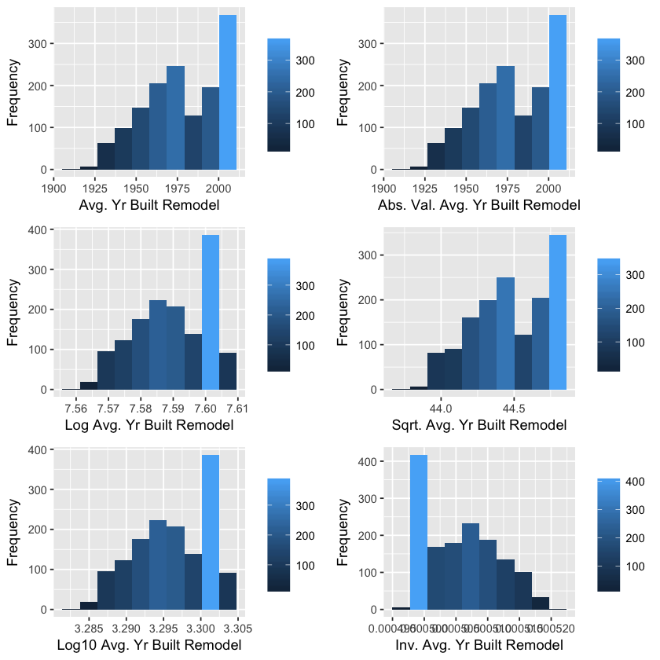

```r
p5 <- ggplot(data= housing, aes(housing$log_year_built_remodel_avg)) + geom_histogram(bins = 10, aes(fill = ..count..))
p5 <- p5 + xlab('Log Avg. Yr Built Remodel') + ylab("Frequency") + theme(legend.title=element_blank())
p6 <- ggplot(data= housing, aes(housing$log10_year_built_remodel_avg)) + geom_histogram(bins = 10, aes(fill = ..count..))
p6 <- p6 + xlab('Log10 Avg. Yr Built Remodel') + ylab("Frequency") + theme(legend.title=element_blank())
p7 <- ggplot(data= housing, aes(housing$abs_year_built_remodel_avg)) + geom_histogram(bins = 10, aes(fill = ..count..))
p7 <- p7 + xlab('Abs. Val. Avg. Yr Built Remodel') + ylab("Frequency") + theme(legend.title=element_blank())
p8 <- ggplot(data= housing, aes(housing$sqrt_year_built_remodel_avg)) + geom_histogram(bins = 10, aes(fill = ..count..))
p8 <- p8 + xlab('Sqrt. Avg. Yr Built Remodel') + ylab("Frequency") + theme(legend.title=element_blank())
p9 <- ggplot(data= housing, aes(housing$inverse_year_built_remodel_avg)) + geom_histogram(bins = 10, aes(fill = ..count..))
p9 <- p9 + xlab('Inv. Avg. Yr Built Remodel') + ylab("Frequency") + theme(legend.title=element_blank())
multiplot(p1, p5, p6, p7,p8, p9, cols = 2)
```

```r
#the data is non-normal
#keep untransformed data or abs
#save names of orig and transformed data to create a subset
year_built_remodel_avg_trans_res <- c("year_built_remodel_avg",
                                           "log_year_built_remodel_avg", "log10_year_built_remodel_avg",
                                           "abs_year_built_remodel_avg", "sqrt_year_built_remodel_avg",
                                           "inverse_year_built_remodel_avg")
#create subset
year_built_remodel_avg_trans_res <- housing[year_built_remodel_avg_trans_res]
```

```r
#run shapiro test for normality on original data and transformed data
yr_built_shap <- lapply(year_built_remodel_avg_trans_res, shapiro.test)
#grab the results of the shapiro test
yr_built_res <- sapply(yr_built_shap, `[`, c("statistic","p.value"))
#print the transposed results
t(yr_built_res)
```

|  | statistic | p.value |
| --- | --- | --- |
| year_built_remodel_avg | 0.9369568 | 2.131928e-24 |
| log_year_built_remodel_avg | 0.9365843 | 1.832276e-24 |
| log10_year_built_remodel_avg | 0.9365843 | 1.832276e-24 |
| abs_year_built_remodel_avg | 0.9369568 | 2.131928e-24 |
| sqrt_year_built_remodel_avg | 0.9367763 | 1.980879e-24 |
| inverse_year_built_remodel_avg | 0.9361658 | 1.546703e-24 |

```r
#log, square root, inverse
housing$log_tot_bsmt_sf_x1st_flr_sf_avg <- log(housing$tot_bsmt_sf_x1st_flr_sf_avg)
housing$log10_tot_bsmt_sf_x1st_flr_sf_avg <- log10(housing$tot_bsmt_sf_x1st_flr_sf_avg)
housing$abs_tot_bsmt_sf_x1st_flr_sf_avg <- abs(housing$tot_bsmt_sf_x1st_flr_sf_avg)
housing$sqrt_tot_bsmt_sf_x1st_flr_sf_avg <- sqrt(housing$tot_bsmt_sf_x1st_flr_sf_avg)
housing$inverse_tot_bsmt_sf_x1st_flr_sf_avg <- 1/(housing$tot_bsmt_sf_x1st_flr_sf_avg)
#year_built_remodel_avg_raw_and_transformation_plots <-
```